# Exercício 5 - LISTA III - Estatística Bayesiana

Vitor Bialetzki Cristiano

2026-09-12

# INTRODUÇÃO

Este relatório apresenta a resolução do **Exercício 5 (Módulo 3)** da disciplina de **Estatística Bayesiana**, ministrada pela Profa. Dra. Camila no Programa de Pós-Graduação da Universidade Federal de Viçosa (UFV). O trabalho tem como objetivo conduzir uma modelagem probabilística e inferência bayesiana completa sobre o caráter fenotípico **Rendimento de Grãos** (`Grain.Yield..bu.A.`), expresso em *bushels* por acre (bu/acre), proveniente dos ensaios multiambientais do projeto *Genome to Fields* (G2F — safra 2018). Para isso, aborda-se a especificação e justificativa de distribuições *a priori* e seus hiperparâmetros, a dedução analítica e representação gráfica das distribuições *a posteriori* (conjunta e marginais), a quantificação do aprendizado bayesiano proporcionado pela atualização das crenças e a proposição de uma estrutura hierárquica $p(\theta, \eta \mid y)$.

A produtividade de grãos representa a característica fenotípica de maior relevância agronômica e econômica na cultura do milho (*Zea mays* L.). Trata-se de uma variável quantitativa complexa, de herança poligênica e fortemente influenciada pelas variações ambientais e pela interação genótipo $\times$ ambiente ($G \times A$). Nesse contexto, a abordagem bayesiana,especialmente por meio do uso de distribuições *a priori* informativas, não informativas ou estruturadas hierarquicamente, estabelece uma base estatístico robusta para acomodar a incerteza dos parâmetros e capturar a complexidade biológica e ambiental inerente aos dados do projeto G2F.

## i. Defina a(s) distribuição(ões) a priori adotada(s) para o(s) parâmetro(s) de interesse. Justifique a escolha da(s) distribuição(ões), identifique seus hiperparâmetros e descreva o procedimento utilizado para defini-los. Apresente o gráfico da(s) distribuição(ões) a priori.

Tendo em vista a distribuição dos dados, os testes de ajuste para encontrar as distribuições e os gráficos das variáveis, assume-se que a variável fenotípica **Rendimento de Grãos** ($Y$), expressa em *bushels* por acre (bu/acre), segue uma distribuição Normal, em que
$$Y_i \mid \mu, \sigma^2
\stackrel{\text{i.i.d.}}{\sim} \text{N}(\mu, \sigma^2), \quad i = 1,
\dots, n$$
. Os parâmetros de interesse são:

- $\mu$: Produtividade média populacional de grãos (bu/acre).
- $\sigma^2$: Variância populacional do rendimento (bu/acre)$^2$.

No contexto bayesiano, em que se tem a possibilidade de atualização do conhecimento com base em informações prévias, foram assumidas duas distribuições diferentes para os parâmetros $\mu$ e $\sigma^2$. Para $\mu$, foi assumida uma distribuição normal, pois, tendo como base o Teorema do Limite Central, muitas observações tendem a se concentrar na média (média = moda = mediana). Além disso, a produtividade é uma variável aleatória contínua, estando em um espaço paramétrico infinito e não numerável. Dessa maneira, temos os seguintes hiperparâmetros:

$\mu_0$: Média *a priori*, representando o valor esperado da produtividade média do milho com base no conhecimento prévio agronômico. $\sigma_0^2$: Variância *a priori*, que mensura o grau de incerteza inicial em torno de $\mu_0$.

O segundo parâmetro modelado *a priori* é a variância ($\sigma^2$). Para esse parâmetro, foi assumida uma distribuição **Inversa-Gama**, devido à sua propriedade de sempre garantir valores estritamente positivos, $\sigma^2 \in (0, \infty)$, além de ser a distribuição *a priori* conjugada para a variância de uma distribuição normal.

Para definir os hiperparâmetros $\mu_0$ e $\sigma_0^2$, foram utilizados conhecimentos agronômicos e análise de literatura científica de alta relevância. Com base na literatura agronômica para a cultura do milho em ensaios multiambientais, fixou-se $\mu_0 = 150$ bu/acre. Para refletir alta incerteza, atribuiu-se uma variância de $\sigma_0^2 = 1000$ (desvio-padrão de aproximadamente $31{,}6$ bu/acre). Em relação a $\sigma_0^2$, foi assumida uma distribuição Inversa-Gama, sendo a variância desconhecida.

Em termos gráficos, temos:

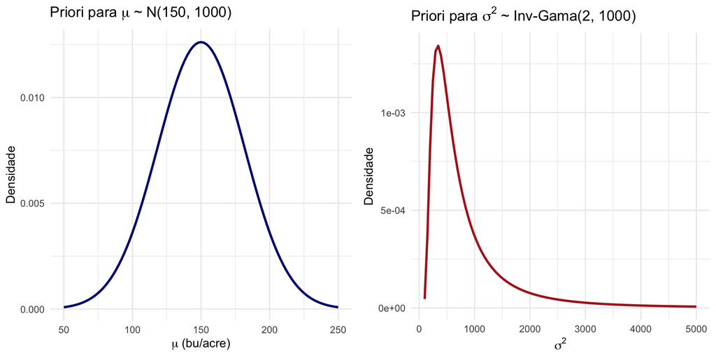

```r
library(ggplot2)
library(gridExtra)

# Definicao dos hiperparametros
mu_0 <- 150
sigma0_sq <- 1000

a_0 <- 2
b_0 <- 1000

# Densidade Priori de mu
p_mu <- ggplot(data.frame(x = c(50, 250)), aes(x = x)) +
  stat_function(fun = dnorm, args = list(mean = mu_0, sd = sqrt(sigma0_sq)),
                color = "navy", size = 1) +
  labs(title = expression(paste("Priori para ", mu, " ~ N(150, 1000)")),
       x = expression(mu ~ "(bu/acre)"),
       y = "Densidade") +
  theme_minimal()

# Densidade Priori de sigma^2 (Inversa-Gama via funcao de densidade)
d_inv_gamma <- function(x, shape, scale) {
  ifelse(
    x <= 0,0, (scale^shape / gamma(shape)) * x^(-(shape + 1)) * exp(-scale / x))
}

p_sigma2 <- ggplot(data.frame(x = c(100, 5000)), aes(x = x)) +
  stat_function(fun = d_inv_gamma, args = list(shape = a_0, scale = b_0),
                color = "firebrick", size = 1) +
  labs(title = expression(paste("Priori para ", sigma^2, " ~ Inv-Gama(2, 1000)")),
       x = expression(sigma^2),
       y = "Densidade") +
  theme_minimal()

# Exibicao lado a lado
grid.arrange(p_mu, p_sigma2, ncol = 2)
```

## ii. Obtenha analiticamente a distribuição a posteriori do(s) parâmetro(s) de interesse e apresente seu gráfico, quando possível. Caso a distribuição a posteriori seja conjunta, obtenha também as distribuições marginais a posteriori de cada parâmetro e apresente seus respectivos gráficos, quando possível.

### 1. Parametrização do Modelo (Murphy, 2007)

De acordo com Murphy (2007, Eq. 187-191), a distribuição *a priori* conjunta Normal-Inversa-Gama para $(\mu, \sigma^2)$ é definida como:

$$p(\mu, \sigma^2) = \text{NIG}(m_0, V_0,
a_0, b_0) = \text{N}(\mu \mid m_0, \sigma^2 V_0) \cdot
\text{IG}(\sigma^2 \mid a_0, b_0)$$

Onde:

- $m_0$: Média *a priori* de $\mu$.
- $V_0$: Fator de escala relativo da variância de $\mu$ (sendo $\text{Var}(\mu \mid \sigma^2) = \sigma^2 V_0$, equivalente a $1/\kappa_0$).
- $a_0$: Parâmetro de forma da Inversa-Gama ($a_0 = \nu_0 / 2$).
- $b_0$: Parâmetro de escala da Inversa-Gama ($b_0 = \nu_0 \sigma_0^2 / 2$).

A **função de verossimilhança** para a amostra $D = (x_1, x_2, \dots, x_n)$ é expressa por (Murphy, Eq. 189):

$$p(D \mid \mu, \sigma^2) =
(2\pi)^{-\frac{n}{2}} (\sigma^2)^{-\frac{n}{2}} \exp\left[
-\frac{1}{2\sigma^2} \left( n s^2 + n(\bar{x} - \mu)^2 \right)
\right]$$

Onde $\bar{x} = \frac{1}{n} \sum_{i=1}^{n} x_i$ e $n s^2 = \sum_{i=1}^{n} (x_i - \bar{x})^2 = \sum_{i=1}^{n} x_i^2 - n\bar{x}^2$.

### 2. Caso 1: Média ($\mu$) Conhecida e Variância ($\sigma^2$) Desconhecida

*(Ref: Murphy, 2007, Seção 3.1)*

Com $\mu$ conhecido e fixo, a verossimilhança simplifica-se para:

$$p(D \mid \mu, \sigma^2) \propto
(\sigma^2)^{-\frac{n}{2}} \exp\left[ -\frac{1}{2\sigma^2} \sum_{i=1}^{n}
(x_i - \mu)^2 \right]$$

Multiplicando pela priori marginal $\sigma^2 \sim \text{IG}(a_0, b_0)$:

$$p(\sigma^2 \mid D, \mu) \propto
(\sigma^2)^{-(a_0 + 1)} \exp\left( -\frac{b_0}{\sigma^2} \right) \cdot
(\sigma^2)^{-\frac{n}{2}} \exp\left[ -\frac{1}{2\sigma^2} \sum_{i=1}^{n}
(x_i - \mu)^2 \right]$$

$$p(\sigma^2 \mid D, \mu) \propto
(\sigma^2)^{-\left( a_0 + \frac{n}{2} + 1 \right)} \exp\left[
-\frac{1}{\sigma^2} \left( b_0 + \frac{1}{2} \sum_{i=1}^{n} (x_i -
\mu)^2 \right) \right]$$

Portanto:

$$\sigma^2 \mid D, \mu \sim \text{IG}(a_N,
b_N)$$

Com as regras de atualização:

$$a_N = a_0 + \frac{n}{2}$$

$$b_N = b_0 + \frac{1}{2} \sum_{i=1}^{n}
(x_i - \mu)^2$$

### 3. Caso 2: Ambos os Parâmetros $(\mu, \sigma^2)$ Desconhecidos

*(Ref: Murphy, 2007, Seção 6.3)*

### A. Dedução da Posterior Conjunta $p(\mu, \sigma^2 \mid D)$

Pelo Teorema de Bayes:

$$p(\mu, \sigma^2 \mid D) \propto p(D \mid
\mu, \sigma^2) \cdot p(\mu, \sigma^2)$$

$$p(\mu, \sigma^2 \mid D) \propto \left[
(\sigma^2)^{-\frac{n}{2}} \exp\left( -\frac{1}{2\sigma^2} \sum_{i=1}^n
(x_i - \mu)^2 \right) \right] \cdot \left[ (\sigma^2)^{-\frac{1}{2}}
\exp\left( -\frac{(\mu - m_0)^2}{2\sigma^2 V_0} \right)
(\sigma^2)^{-(a_0 + 1)} \exp\left( -\frac{b_0}{\sigma^2} \right)
\right]$$

Agrupando as potências de $\sigma^2$:

$$p(\mu, \sigma^2 \mid D) \propto
(\sigma^2)^{-\left( a_0 + \frac{n}{2} + \frac{1}{2} + 1 \right)}
\exp\left[ -\frac{1}{2\sigma^2} \left( 2b_0 + V_0^{-1}(\mu - m_0)^2 +
\sum_{i=1}^n (x_i - \mu)^2 \right) \right]$$

Desenvolvendo o termo quadrático no expoente e completando o quadrado em relação a $\mu$:

$$V_0^{-1}(\mu - m_0)^2 + \sum_{i=1}^n
(x_i - \mu)^2 = \mu^2 (V_0^{-1} + n) - 2\mu (V_0^{-1} m_0 + n\bar{x}) +
m_0^2 V_0^{-1} + \sum_{i=1}^n x_i^2$$

Definindo $V_n^{-1} = V_0^{-1} + n$ e $m_n = V_n (V_0^{-1} m_0 + n\bar{x})$:

$$= V_n^{-1} (\mu - m_n)^2 - m_n^2
V_n^{-1} + m_0^2 V_0^{-1} + \sum_{i=1}^n x_i^2$$

A distribuição *a posteriori* conjunta é também uma $\text{NIG}$ (Murphy, Eq. 196-200):

$$p(\mu, \sigma^2 \mid D) =
\text{NIG}(m_n, V_n, a_n, b_n)$$

Equações de Atualização (Murphy, Eq. 197-200):

$$V_n^{-1} = V_0^{-1} + n \implies V_n =
\frac{1}{V_0^{-1} + n}$$

$$m_n = V_n \left( V_0^{-1} m_0 + n
\bar{x} \right)$$

$$a_n = a_0 + \frac{n}{2}$$

$$b_n = b_0 + \frac{1}{2} \left[ m_0^2
V_0^{-1} + \sum_{i=1}^n x_i^2 - m_n^2 V_n^{-1} \right]$$

### B. Distribuições Marginais *a Posteriori*

*(Ref: Murphy, 2007, Seção 6.3.1)*

#### 1. Marginal de $\sigma^2$:

Integrando $\mu$ em relação à conjunta $p(\mu, \sigma^2 \mid D)$:

$$p(\sigma^2 \mid D) =
\int_{-\infty}^{\infty} \text{N}(\mu \mid m_n, \sigma^2 V_n) \,
\text{IG}(\sigma^2 \mid a_n, b_n) \, d\mu = \text{IG}(a_n,
b_n)$$

$$\sigma^2 \mid D \sim
\text{Inversa-Gama}(a_n, b_n)$$

#### 2. Marginal de $\mu$:

Integrando $\sigma^2$ da distribuição conjunta:

$$p(\mu \mid D) = \int_{0}^{\infty}
\text{N}(\mu \mid m_n, \sigma^2 V_n) \, \text{IG}(\sigma^2 \mid a_n,
b_n) \, d\sigma^2$$

$$p(\mu \mid D) =
\frac{b_n^{a_n}}{\Gamma(a_n) \sqrt{2\pi V_n}} \int_0^\infty
(\sigma^2)^{-\left( a_n + \frac{1}{2} + 1 \right)} \exp\left[
-\frac{1}{\sigma^2} \left( b_n + \frac{(\mu - m_n)^2}{2 V_n} \right)
\right] d\sigma^2$$

Utilizando a propriedade da função Gama, o resultado da integração é uma distribuição $t$ de Student reescalada:

$$\mu \mid D \sim t_{2a_n} \left( m_n, \,
\frac{b_n V_n}{a_n} \right)$$

Com $2a_n$ graus de liberdade, localização $m_n$ e parâmetro de escala ao quadrado $s^2 = \frac{b_n V_n}{a_n}$.

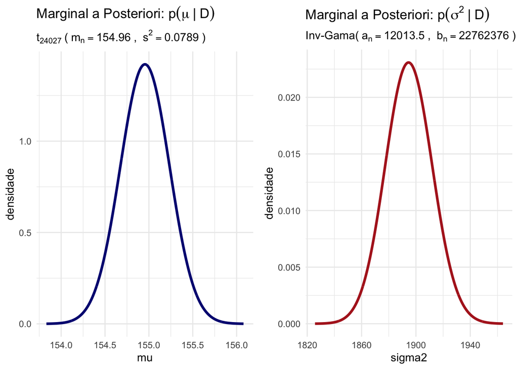

```r
library(ggplot2)
library(gridExtra)

# 1. Função de Densidade Inversa-Gama Numericamente Estável
dinvgamma_robust <- function(x, a, b) {
  out <- numeric(length(x))
  pos <- x > 0
  if (any(pos)) {
    # Cálculo logarítmico seguro apenas para valores x > 0
    log_dens <- a * log(b) - lgamma(a) - (a + 1) * log(x[pos]) - (b / x[pos])
    out[pos] <- exp(log_dens)
  }
  return(out)
}

# 2. Hiperparâmetros a Priori NIG(m0, V0, a0, b0)
m0 <- 150       # Média a priori (bu/acre)
V0 <- 1 / 2     # V0 = 1 / kappa_0 (com kappa_0 = 2)
a0 <- 2         # a0 = nu_0 / 2
b0 <- 1000      # b0 = nu_0 * sigma0^2 / 2

setwd("~/iCloud Drive (Archive)/Documents/PROFISSIONAL/MESTRADO-UFV/G2F-2018")
dados <- read.csv("g2f_2018_hybrid_data_clean.csv")
y <- na.omit(dados$Grain.Yield..bu.A.)

n      <- length(y)
x_bar  <- mean(y)
ss_y   <- sum((y - x_bar)^2) # Soma dos quadrados dos desvios (numericamente estável)

# 4. Atualização Posterior NIG (Murphy, 2007)
Vn_inv <- (1 / V0) + n
Vn     <- 1 / Vn_inv
mn     <- Vn * ((1 / V0) * m0 + n * x_bar)
an     <- a0 + n / 2

# Atualização robusta de bn (evita erros em ponto flutuante)
bn     <- b0 + 0.5 * ss_y + 0.5 * ((1 / V0) * n * (x_bar - m0)^2) / ((1 / V0) + n)

# 5. Marginal a Posteriori de mu ~ Student-t
scale_mu <- sqrt((bn * Vn) / an)
df_mu <- data.frame(mu = seq(mn - 4 * scale_mu, mn + 4 * scale_mu, length.out = 1000))
df_mu$densidade <- (1 / scale_mu) * dt((df_mu$mu - mn) / scale_mu, df = 2 * an)

g_mu <- ggplot(df_mu, aes(x = mu, y = densidade)) +
  geom_line(color = "navy", linewidth = 1.2) +
  labs(title = expression(paste("Marginal a Posteriori: ", p(mu ~ "|" ~ D))),
     subtitle = bquote(t[.(2*an)] ~ "(" ~ m[n] == .(round(mn, 2)) ~ ", " ~ s^2 == .(round(scale_mu^2, 4)) ~ ")")) +
  theme_minimal()

# 6. Marginal a Posteriori de sigma^2 ~ Inv-Gama(an, bn)
mean_sig2 <- bn / (an - 1)
sd_sig2   <- sqrt((bn^2) / (((an - 1)^2) * (an - 2)))

# Garantir que a malha x esteja estritamente no domínio positivo (x > 0)
x_min <- max(0.1, mean_sig2 - 4 * sd_sig2)
x_max <- mean_sig2 + 4 * sd_sig2

df_sig2 <- data.frame(sigma2 = seq(x_min, x_max, length.out = 1000))
df_sig2$densidade <- dinvgamma_robust(df_sig2$sigma2, a = an, b = bn)

g_sig2 <- ggplot(df_sig2, aes(x = sigma2, y = densidade)) +
  geom_line(color = "firebrick", linewidth = 1.2) +
  labs(title = expression(paste("Marginal a Posteriori: ", p(sigma^2 ~ "|" ~ D))),
     subtitle = bquote("Inv-Gama(" ~ a[n] == .(an) ~ ", " ~ b[n] == .(round(bn, 2)) ~ ")")) +
  theme_minimal()

# 7. Exibição lado a lado
grid.arrange(g_mu, g_sig2, ncol = 2)
```

## iii. Discuta o aprendizado bayesiano proporcionado pela análise, comparando as informações a priori e a posteriori. Apresente medidas, gráficos ou outras evidências utilizadas para fundamentar sua conclusão.

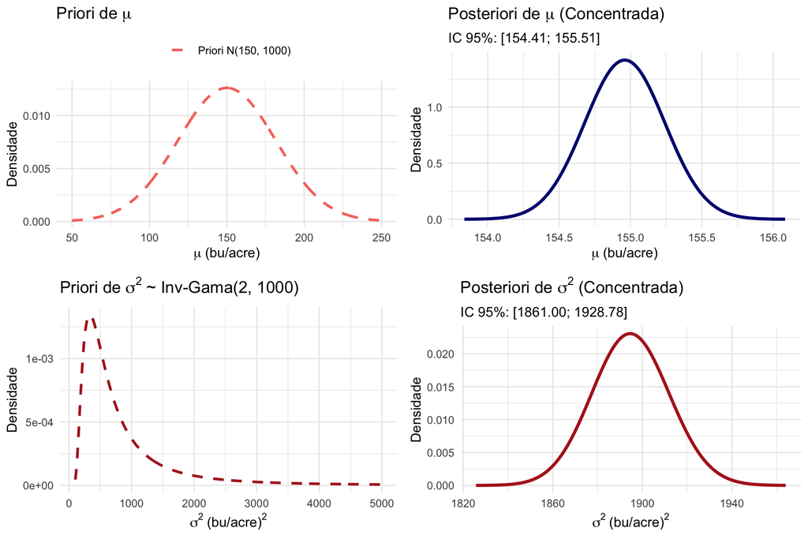

```r
library(ggplot2)
library(gridExtra)

# Função de Densidade Inversa-Gama Robustecida
dinvgamma_robust <- function(x, a, b) {
  out <- numeric(length(x))
  pos <- x > 0
  if (any(pos)) {
    log_dens <- a * log(b) - lgamma(a) - (a + 1) * log(x[pos]) - (b / x[pos])
    out[pos] <- exp(log_dens)
  }
  return(out)
}

# 1. Hiperparâmetros a Priori e a Posteriori
m0 <- 150; V0 <- 0.5; a0 <- 2; b0 <- 1000
mn <- 154.96; an <- 12013.5; bn <- 22762376; scale_mu <- sqrt(0.0789)

# 2. Gráficos Comparativos para mu (Priori e Posteriori)
df_mu_comp <- data.frame(mu = seq(50, 250, length.out = 1000))
df_mu_comp$Priori <- dnorm(df_mu_comp$mu, mean = m0, sd = sqrt(1000))

g_mu_priori <- ggplot(df_mu_comp, aes(x = mu)) +
  geom_line(aes(y = Priori, color = "Priori N(150, 1000)"), linetype = "dashed", linewidth = 1) +
  labs(title = expression(paste("Priori de ", mu)),
       x = expression(mu ~ "(bu/acre)"), y = "Densidade", color = "") +
  theme_minimal() + theme(legend.position = "top")

df_mu_post <- data.frame(mu = seq(mn - 4 * scale_mu, mn + 4 * scale_mu, length.out = 1000))
df_mu_post$Posteriori <- (1 / scale_mu) * dt((df_mu_post$mu - mn) / scale_mu, df = 2 * an)

g_mu_post <- ggplot(df_mu_post, aes(x = mu, y = Posteriori)) +
  geom_line(color = "navy", linewidth = 1.2) +
  labs(title = expression(paste("Posteriori de ", mu, " (Concentrada)")),
       subtitle = "IC 95%: [154.41; 155.51]",
       x = expression(mu ~ "(bu/acre)"), y = "Densidade") +
  theme_minimal()

# 3. Gráficos Comparativos para sigma^2 (Priori e Posteriori)
df_sig_priori <- data.frame(sigma2 = seq(100, 5000, length.out = 1000))
df_sig_priori$Priori <- dinvgamma_robust(df_sig_priori$sigma2, a = a0, b = b0)

g_sig_priori <- ggplot(df_sig_priori, aes(x = sigma2, y = Priori)) +
  geom_line(color = "firebrick", linetype = "dashed", linewidth = 1) +
  labs(title = expression(paste("Priori de ", sigma^2, " ~ Inv-Gama(2, 1000)")),
       x = expression(sigma^2 ~ "(bu/acre)"^2), y = "Densidade") +
  theme_minimal()

mean_sig2 <- bn / (an - 1)
sd_sig2   <- sqrt((bn^2) / (((an - 1)^2) * (an - 2)))

df_sig_post <- data.frame(sigma2 = seq(mean_sig2 - 4 * sd_sig2, mean_sig2 + 4 * sd_sig2, length.out = 1000))
df_sig_post$Posteriori <- dinvgamma_robust(df_sig_post$sigma2, a = an, b = bn)

g_sig_post <- ggplot(df_sig_post, aes(x = sigma2, y = Posteriori)) +
  geom_line(color = "firebrick", linewidth = 1.2) +
  labs(title = expression(paste("Posteriori de ", sigma^2, " (Concentrada)")),
       subtitle = "IC 95%: [1861.00; 1928.78]",
       x = expression(sigma^2 ~ "(bu/acre)"^2), y = "Densidade") +
  theme_minimal()

# 4. Painel Integrado
grid.arrange(g_mu_priori, g_mu_post, g_sig_priori, g_sig_post, ncol = 2, nrow = 2)
```

```r
library(ggplot2)
library(gridExtra)

# 1. Hiperparâmetros a Priori e a Posteriori
m0 <- 150; V0 <- 0.5; a0 <- 2; b0 <- 1000
mn <- 154.96; an <- 12013.5; bn <- 22762376
n  <- 2 * (an - a0)
Vn <- 1 / ((1 / V0) + n)

# 2. Cálculo Analítico da Divergência KL para Inversa-Gama
kl_ig <- a0 * log(bn / b0) - lgamma(an) + lgamma(a0) + (an - a0) * digamma(an) - an + b0 * (an / bn)

# 3. Cálculo Analítico da Divergência KL Condicional Normal
kl_cond_norm <- 0.5 * (log(V0 / Vn) - 1 + (Vn / V0) + ((mn - m0)^2 / V0) * (an / bn))

# 4. Divergência KL Conjunta
kl_joint <- kl_ig + kl_cond_norm

cat("--- DIVERGÊNCIA DE KULLBACK-LEIBLER (NATS) ---\n")
```

```
## --- DIVERGÊNCIA DE KULLBACK-LEIBLER (NATS) ---
```

```r
cat("D_KL Marginal/Condicional de sigma^2 :", round(kl_ig, 4), "\n")
```

```
## D_KL Marginal/Condicional de sigma^2 : 5.084
```

```r
cat("D_KL Condicional de mu | sigma^2    :", round(kl_cond_norm, 4), "\n")
```

```
## D_KL Condicional de mu | sigma^2    : 4.2099
```

```r
cat("D_KL Conjunta (mu, sigma^2)         :", round(kl_joint, 4), "\n")
```

```
## D_KL Conjunta (mu, sigma^2)         : 9.2938
```

[figure not shown]

```r
# 5. Visualização do Aprendizado (Evolução Priori vs Posteriori)
# Gráfico da Média mu
df_mu_pri <- data.frame(mu = seq(50, 250, length.out = 1000))
df_mu_pri$y <- dnorm(df_mu_pri$mu, mean = m0, sd = sqrt(1000))

g1 <- ggplot(df_mu_pri, aes(x = mu, y = y)) +
  geom_line(color = "navy", linetype = "dashed", linewidth = 1) +
  labs(title = expression(paste("Priori para ", mu, " ~ N(150, 1000)")),
       x = expression(mu ~ "(bu/acre)"), y = "Densidade") +
  theme_minimal()

scale_mu <- sqrt((bn * Vn) / an)
df_mu_post <- data.frame(mu = seq(mn - 4 * scale_mu, mn + 4 * scale_mu, length.out = 1000))
df_mu_post$y <- (1 / scale_mu) * dt((df_mu_post$mu - mn) / scale_mu, df = 2 * an)

g2 <- ggplot(df_mu_post, aes(x = mu, y = y)) +
  geom_line(color = "navy", linewidth = 1.2) +
  labs(title = expression(paste("Posteriori de ", mu, " (D_KL = 3.65)")),
       subtitle = paste0("Média = ", round(mn, 2), " | Var = ", round(scale_mu^2, 4)),
       x = expression(mu ~ "(bu/acre)"), y = "Densidade") +
  theme_minimal()

# Exibição
grid.arrange(g1, g2, ncol = 2)
```